# Kenai early run 2024 forecast

Nick DeCovich

2023-11-06

## Age 5 models

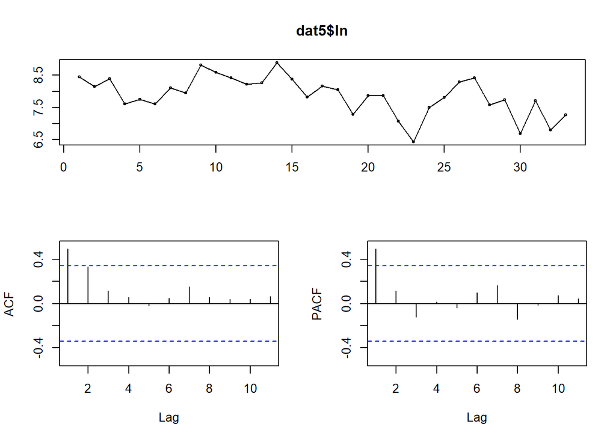

```r
#Moving average model
## hindcast predictions
dat5$ma5_pred <- pred_ma(dat5$ln, yrs = 5)[, "median"]

#ARIMA
forecast::tsdisplay(dat5$ln)
```

```r
forecast::auto.arima(dat5$ln) # wants to difference with a ma term
```

```
## Series: dat5$ln
## ARIMA(0,1,1)
##
## Coefficients:
##           ma1
##       -0.4784
## s.e.   0.2157
##
## sigma^2 = 0.2824:  log likelihood = -24.79
## AIC=53.59   AICc=54   BIC=56.52
```

```r
mu_ARIMA5 <- arima(dat5$ln, order=c(0,1,1))
summary(mu_ARIMA5)
```

```
##
## Call:
## arima(x = dat5$ln, order = c(0, 1, 1))
##
## Coefficients:
##           ma1
##       -0.4784
## s.e.   0.2157
##
## sigma^2 estimated as 0.2735:  log likelihood = -24.79,  aic = 53.59
##
## Training set error measures:
##                      ME      RMSE       MAE       MPE     MAPE      MASE
## Training set -0.0694632 0.5150161 0.4082743 -1.235375 5.375863 0.8636134
##                    ACF1
## Training set 0.01754854
```

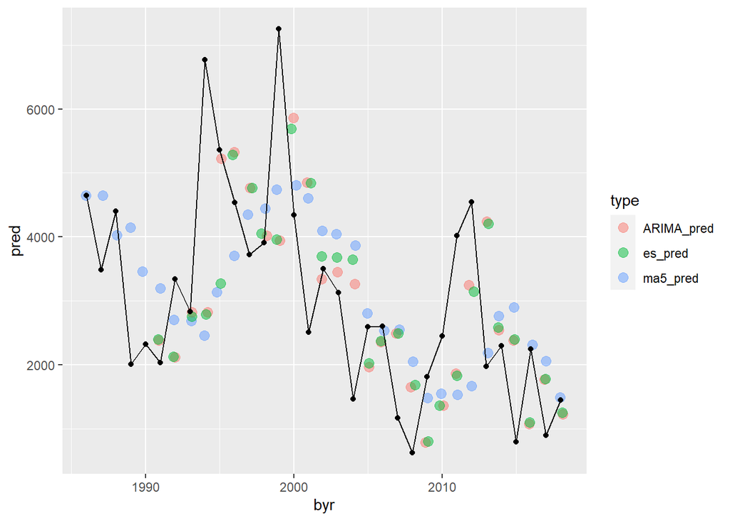

```
##
## [[2]]
## # A tibble: 3 × 4
##   type          md   mad  mape
##   <chr>      <dbl> <dbl> <dbl>
## 1 ARIMA_pred  261.  818. 0.748
## 2 es_pred     285.  820. 0.752
## 3 ma5_pred    766.  766. 0.838
```

```r
## hindcast predictions
temp5U <- pred_arima(mu_ARIMA5, x = dat5$ln)
dat5$ARIMA_pred <- exp(temp5U[1,])

#exponential smoothing
ets5 <- forecast::ets(dat5$ln)
## hindcast predictions
dat5$es_pred <- pred_es(dat5$ln)

#compare models
(comp_age5 <- comp_models(dat5, comp_age = 5, years = 5, metric = c("md", "mad", "mape")))
```

```r
# dat5 %>%
#   dplyr::select(byr, age5, dplyr::ends_with("pred")) %>%
#   tidyr::gather(type, pred, -byr, -age5) %>%
#   dplyr::mutate(d = pred - age5,
#                 pe = d/age5) %>%
#   filter(byr %in% 2014:2018)
```

## Age 5 forecast table

For me (Adam), this is a tricky choice. The mad would suggest the moving average but notice we have missed high every single year. I picked the ARIMA model but it is open to debate. Not much consequence with any choice.

```r
## Moving average forecast
#tail(dat5)
forecast5_ma5 <- exp(mean(dat5$ln[29:33]))

#univariate ARIMA
forecast5_2024 <- forecast5_ARIMA <- exp(predict(mu_ARIMA5, n.ahead = 1)$pred)

#exponential smoothing
forecast5_es <- exp(predict(ets5, h = 1)[["mean"]][1])

#merge 2024 forecast estimate for each model with MAD table
named_df <- function(...){
    names <- as.list(substitute(list(...)))[-1L]
    result <- list(...)
    list(names, result) %>% as.data.frame()
    data.frame(name = as.character(names),
               forecast = round(as.numeric(result), 0)) %>%
      mutate(mod = gsub(".*_(.*)", "\\1", name))
}

comp_age5[[2]] %>%
  mutate(mod = gsub("(.*)_.*", "\\1", type)) %>%
  right_join(named_df(forecast5_ma5, forecast5_ARIMA, forecast5_es), by = "mod") %>%
  select(mod, forecast, md, mad, mape)
```

```
## # A tibble: 3 × 5
##   mod   forecast    md   mad  mape
##   <chr>    <dbl> <dbl> <dbl> <dbl>
## 1 ARIMA     1342  261.  818. 0.748
## 2 es        1352  285.  820. 0.752
## 3 ma5       1396  766.  766. 0.838
```

## Age 6 models

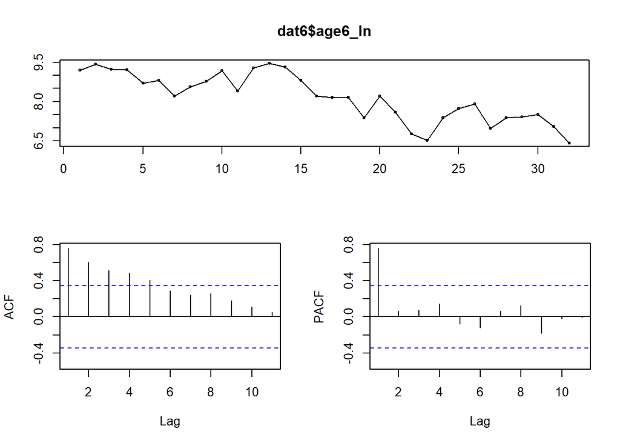

```r
#Moving average
#hindcast predictions
dat6$ma5_pred <- pred_ma(dat6$age6_ln, yrs = 5)[, "median"]

#univariate
forecast::tsdisplay(dat6$age6_ln)
```

```r
forecast::auto.arima(dat6$age6_ln) # wants to difference
```

```
## Series: dat6$age6_ln
## ARIMA(0,1,0)
##
## sigma^2 = 0.2592:  log likelihood = -23.06
## AIC=48.12   AICc=48.26   BIC=49.55
```

```r
mu_ARIMA6 <- arima(dat6$age6_ln, order=c(0,1,0))
summary(mu_ARIMA6)
```

```
##
## Call:
## arima(x = dat6$age6_ln, order = c(0, 1, 0))
##
##
## sigma^2 estimated as 0.2592:  log likelihood = -23.06,  aic = 48.12
##
## Training set error measures:
##                       ME      RMSE       MAE       MPE     MAPE      MASE
## Training set -0.08671064 0.5011116 0.4062327 -1.332012 5.185942 0.9694357
##                    ACF1
## Training set -0.1806478
```

```r
#hindcast predictions
temp6U <- pred_arima(mu_ARIMA6, x = dat6$age6_ln)
dat6$ARIMA_pred <- exp(temp6U[1,])

#exponential smoothing
ets6 <- forecast::ets(dat6$age6_ln)
#hindcast predictions
dat6$es_pred <- pred_es(dat6$age6_ln)
```

The sibling model used here is a little different than the one Tony has been using. I’d name this one “Sibling Model” and describe it as “A regression between the natural logs of abundance in an age class and the most recent return of siblings from the same brood year”. This is the same language Nick uses.

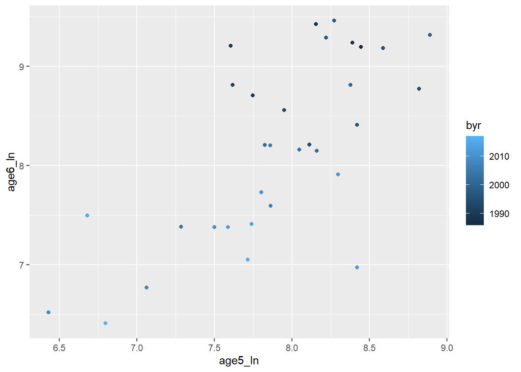

```r
#sibling model
ggplot2::ggplot(dat6, ggplot2::aes(x = age5_ln, y = age6_ln, color = byr)) +
  ggplot2::geom_point()
```

```r
sib6 <- lm(age6_ln ~ age5_ln, data = dat6)
summary(sib6)
```

```
##
## Call:
## lm(formula = age6_ln ~ age5_ln, data = dat6)
##
## Residuals:
##      Min       1Q   Median       3Q      Max
## -1.76291 -0.40852 -0.08852  0.46009  1.35441
##
## Coefficients:
##             Estimate Std. Error t value Pr(>|t|)
## (Intercept)  -0.3951     1.6064  -0.246    0.807
## age5_ln       1.0841     0.2029   5.343 8.83e-06 ***
## ---
## Signif. codes:  0 '***' 0.001 '**' 0.01 '*' 0.05 '.' 0.1 ' ' 1
##
## Residual standard error: 0.6627 on 30 degrees of freedom
## Multiple R-squared:  0.4876, Adjusted R-squared:  0.4706
## F-statistic: 28.55 on 1 and 30 DF,  p-value: 8.831e-06
```

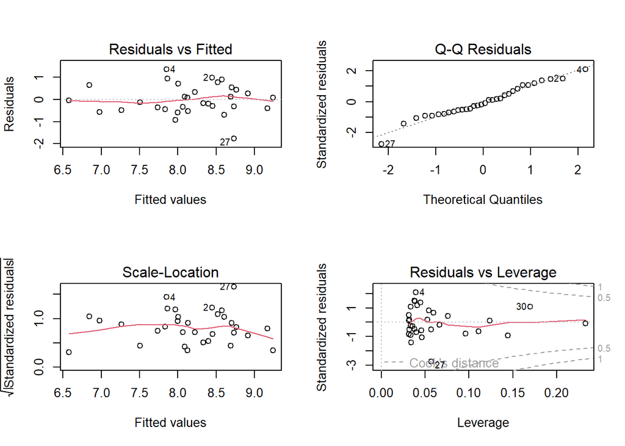

```r
par(mfrow = c(2,2)); plot(sib6); par(mfrow = c(1,1))
```

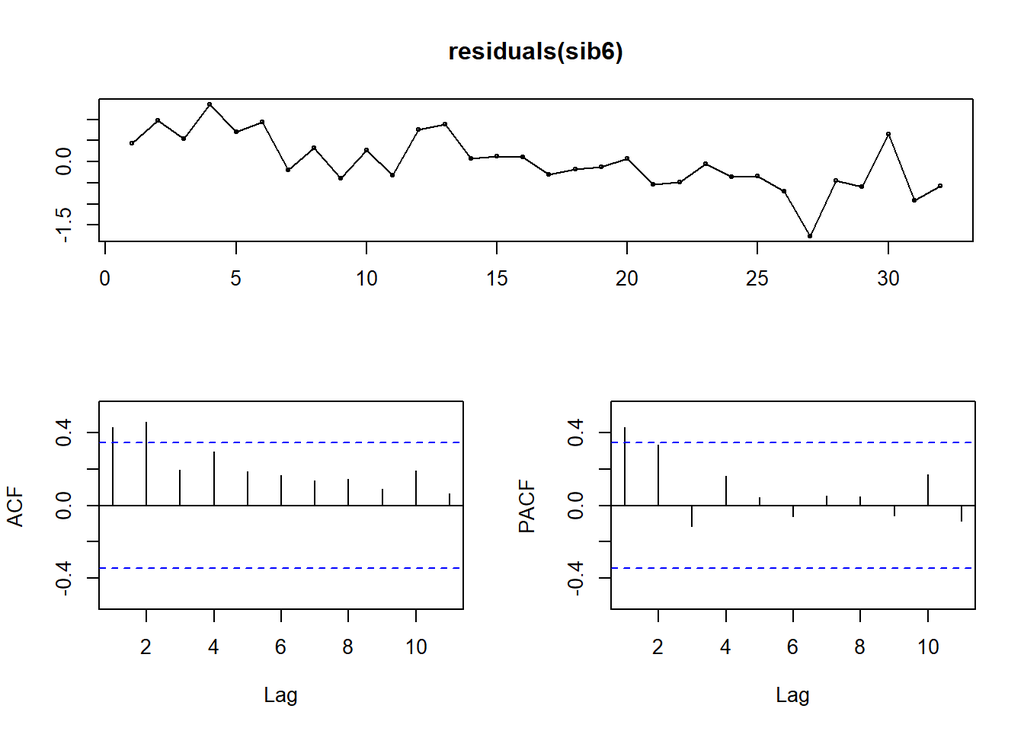

```r
# temp6 <- pred_lm(sib6) #compare regular sibling with the ARIMA sibling (ARIMA sibling much lower 5 year mad)
# dat6$sibling_pred <- exp(temp6[1,])
forecast::tsdisplay(residuals(sib6))
```

```r
forecast::auto.arima(sib6$model$age6_ln, xreg = sib6$model$age5_ln) #suggests we should difference with a ma term.
```

```
## Series: sib6$model$age6_ln
## Regression with ARIMA(0,1,1) errors
##
## Coefficients:
##           ma1    xreg
##       -0.4658  0.4362
## s.e.   0.1949  0.1731
##
## sigma^2 = 0.22:  log likelihood = -19.61
## AIC=45.21   AICc=46.1   BIC=49.51
```

```r
sib6_diffma <- arima(sib6$model$age6_ln, order=c(0,1,1), xreg = sib6$model$age5_ln, method = "ML")
sib6_diffma
```

```
##
## Call:
## arima(x = sib6$model$age6_ln, order = c(0, 1, 1), xreg = sib6$model$age5_ln,
##     method = "ML")
##
## Coefficients:
##           ma1  sib6$model$age5_ln
##       -0.4659              0.4362
## s.e.   0.1949              0.1731
##
## sigma^2 estimated as 0.2058:  log likelihood = -19.61,  aic = 45.21
```

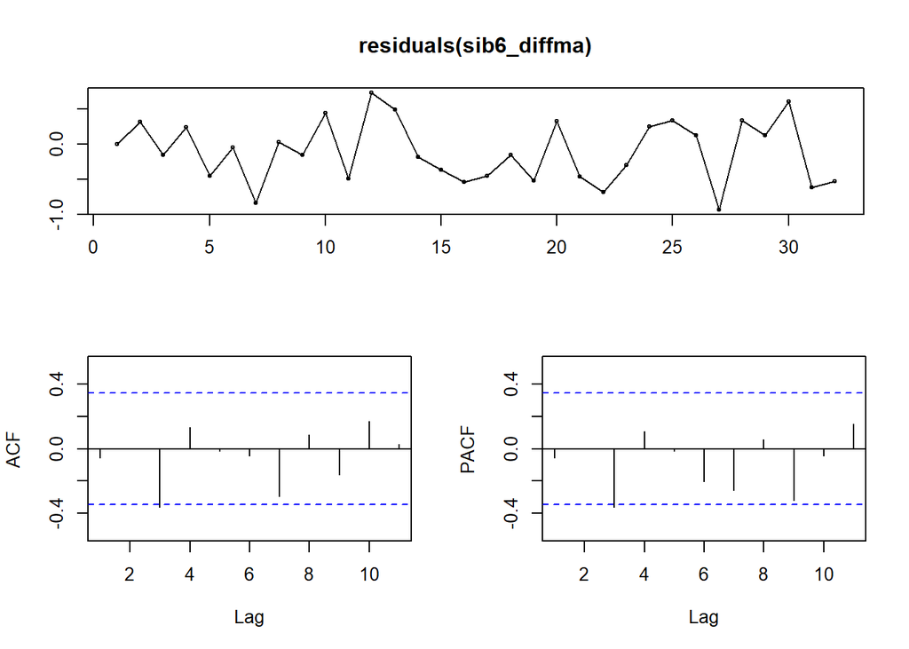

```r
forecast::tsdisplay(residuals(sib6_diffma)) #better
```

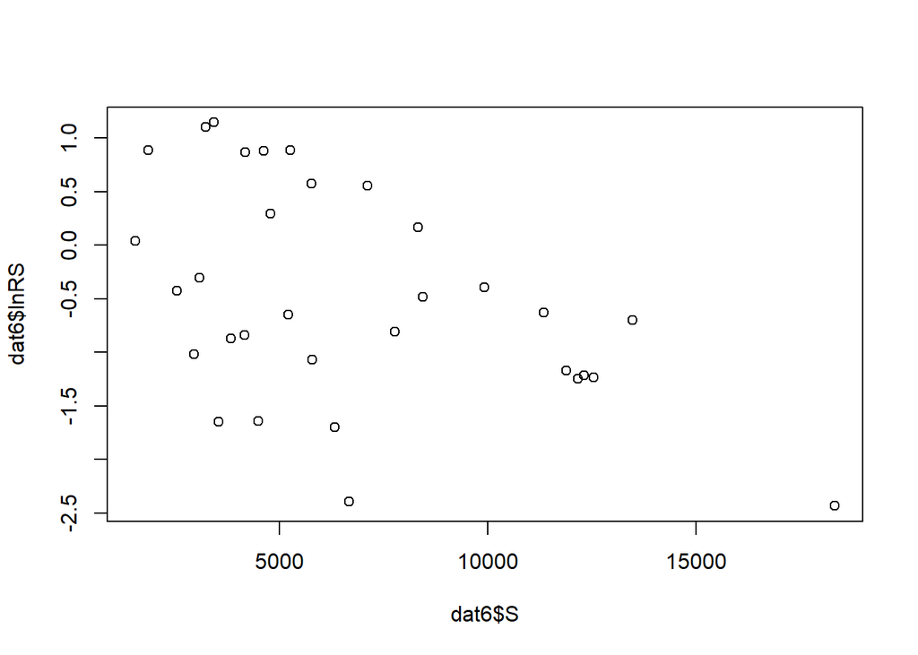

```r
## hindcast predictions
dat6$sibling_pred <- exp(pred_arima(sib6_diffma, x = sib6$model$age6_ln, xreg = sib6$model$age5_ln)[1,])

#ricker
plot(dat6$S, dat6$lnRS)
```

```r
rick6 <- lm(lnRS ~ S, data = dat6)
summary(rick6)
```

```
##
## Call:
## lm(formula = lnRS ~ S, data = dat6)
##
## Residuals:
##      Min       1Q   Median       3Q      Max
## -1.92461 -0.61097 -0.08527  0.80142  1.23712
##
## Coefficients:
##               Estimate Std. Error t value Pr(>|t|)
## (Intercept)  3.124e-01  3.121e-01   1.001  0.32477
## S           -1.174e-04  3.968e-05  -2.960  0.00596 **
## ---
## Signif. codes:  0 '***' 0.001 '**' 0.01 '*' 0.05 '.' 0.1 ' ' 1
##
## Residual standard error: 0.8953 on 30 degrees of freedom
## Multiple R-squared:  0.226,  Adjusted R-squared:  0.2002
## F-statistic:  8.76 on 1 and 30 DF,  p-value: 0.005964
```

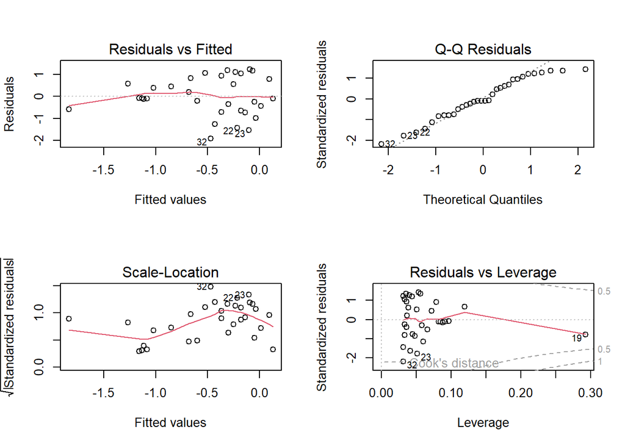

```r
par(mfrow = c(2,2)); plot(rick6); par(mfrow = c(1,1))
```

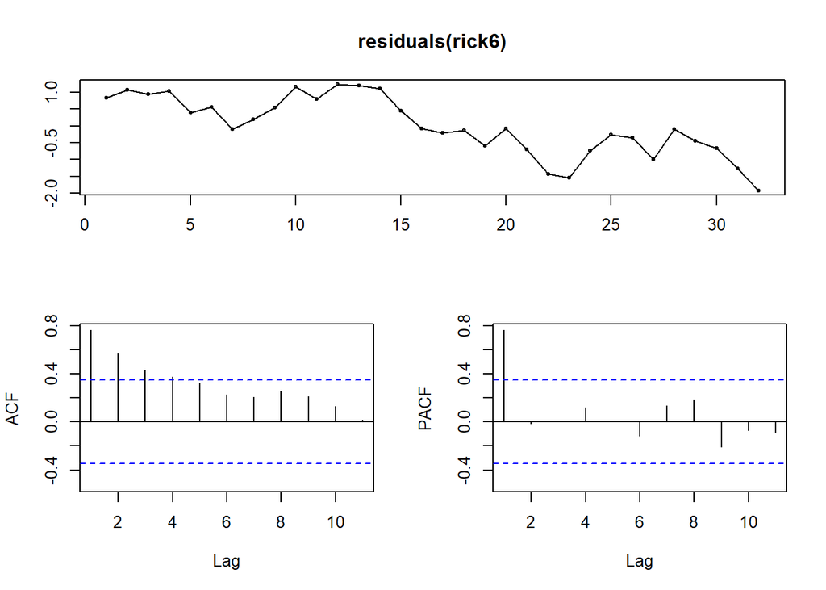

```r
forecast::tsdisplay(residuals(rick6))
```

```r
forecast::auto.arima(rick6$model$lnRS, xreg = rick6$model$S)
```

```
## Series: rick6$model$lnRS
## Regression with ARIMA(0,1,0) errors
##
## Coefficients:
##         xreg
##       -2e-04
## s.e.   2e-04
##
## sigma^2 = 0.2225:  log likelihood = -20.18
## AIC=44.37   AICc=44.8   BIC=47.24
```

```r
rick6_ar1 <- arima(rick6$model$lnRS, order=c(0,1,0), xreg = rick6$model$S, method = "ML")
rick6_ar1
```

```
##
## Call:
## arima(x = rick6$model$lnRS, order = c(0, 1, 0), xreg = rick6$model$S, method = "ML")
##
## Coefficients:
##       rick6$model$S
##              -2e-04
## s.e.          2e-04
##
## sigma^2 estimated as 0.2153:  log likelihood = -20.18,  aic = 44.37
```